# p8131_hw10_mp3745

Matthew Parker

2020-05-02

## Problem 1

Test H0 : h1(t) = h2(t) for all t, H1 : h1(t) ̸= h2(t) for some t using the log-rank test.

```r
# Enter in the data
data = tibble(
  time = c(4, 12, 15, 21, 23, 2, 6, 8, 10, 19),
  cens = c(1, 0, 1, 0, 1, 1, 0, 0, 1, 1),
  group = c(1, 1, 1, 1, 1, 2, 2, 2, 2, 2)
)

# Test hypothesis with log rank test
survdiff(Surv(time, cens) ~ group, data = data)
```

```
## Call:
## survdiff(formula = Surv(time, cens) ~ group, data = data)
##
##         N Observed Expected (O-E)^2/E (O-E)^2/V
## group=1 5        3     4.14     0.313      1.15
## group=2 5        3     1.86     0.697      1.15
##
##  Chisq= 1.1  on 1 degrees of freedom, p= 0.3
```

## Problem 2

Read in the data

```r
data("kidtran")
```

Compare the survival curves for different races in each sex group

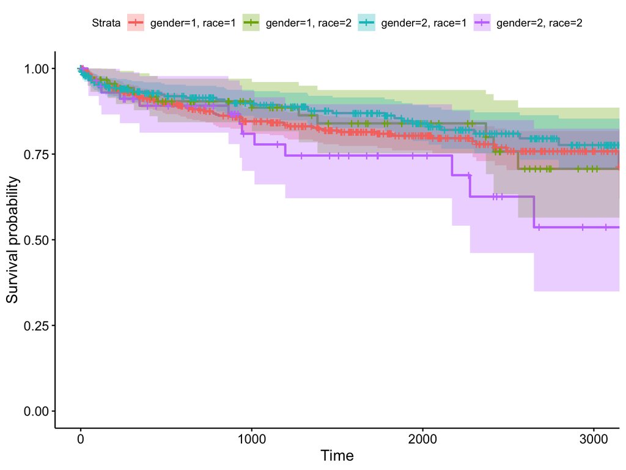

```r
ggsurvplot(survfit(Surv(time, delta) ~ gender + race, data = kidtran), conf.int = TRUE)
```

Based on the above survival curves, it looks like gender = 2 and race = 2 have the worse survival. The survival curves for the other race/gender groups are fairly similar and better than gender = 2, race = 2.

## Problem 3

Read in the data

```r
data("larynx")

# convert stage 2 to single binary column
larynx_bin = larynx %>%
  mutate(
    stage_1 = as.factor(if_else(stage == 1, 1, 0)),
    stage_2 = as.factor(if_else(stage == 2, 1, 0)),
    stage_3 = as.factor(if_else(stage == 3, 1, 0)),
    stage_4 = as.factor(if_else(stage == 4, 1, 0)),
    stage = as.factor(stage)
  )
```

Fit a proportional hazards model using the covariates Z1, Z2, Z3, Z4 and the interaction term Z1 * Z4

```r
ph_mod = coxph(Surv(time, delta) ~ stage_2 + stage_3 + stage_4 + age + stage_2 * age, data = larynx_bin, ties = 'breslow')

summary(ph_mod)
```

```
## Call:
## coxph(formula = Surv(time, delta) ~ stage_2 + stage_3 + stage_4 +
##     age + stage_2 * age, data = larynx_bin, ties = "breslow")
##
##   n= 90, number of events= 50
##
##                    coef  exp(coef)   se(coef)      z Pr(>|z|)
## stage_21     -7.3820143  0.0006223  3.4027542 -2.169   0.0301 *
## stage_31      0.6218044  1.8622853  0.3558078  1.748   0.0805 .
## stage_41      1.7534270  5.7743576  0.4239595  4.136 3.54e-05 ***
## age           0.0059729  1.0059908  0.0148792  0.401   0.6881
## stage_21:age  0.1116674  1.1181409  0.0476728  2.342   0.0192 *
## ---
## Signif. codes:  0 '***' 0.001 '**' 0.01 '*' 0.05 '.' 0.1 ' ' 1
##
##              exp(coef) exp(-coef) lower .95 upper .95
## stage_21     0.0006223  1606.8231 7.900e-07    0.4903
## stage_31     1.8622853     0.5370 9.272e-01    3.7403
## stage_41     5.7743576     0.1732 2.516e+00   13.2550
## age          1.0059908     0.9940 9.771e-01    1.0358
## stage_21:age 1.1181409     0.8943 1.018e+00    1.2277
##
## Concordance= 0.682  (se = 0.04 )
## Likelihood ratio test= 24.11  on 5 df,   p=2e-04
## Wald test            = 23.77  on 5 df,   p=2e-04
## Score (logrank) test = 27.98  on 5 df,   p=4e-05
```

From the model, age is not significantly related to time to death, holding stage constant. The hazard ratio between stage 2 and stage 1, while holding age constant is 0.0006. The hazard ratio between stage 3 and stage 1, while holding age constant is 1.862. The hazard ratio between stage 4 and stage 1, while holding age constant is 5.774. There is a significant stage 2 by age interaction term in time to death.

The relative risk of dying for a stage II patient of age 50 as compared to a stage I patient of the same age is 0.1655231.